# Is Australia going to meet its 2030 Greenhouse Gas Emissions Targets?

Last updated: 25 October, 2024

## Introduction

- Australia has been investing in renewable energy increasingly after ratifying the NFCCC’s Kyoto Protocol in 2007.
- Under it’s first commitment (2008-2012), it set a target of not exceeding 108% of it’s greenhouse gas emissions in 1990.
- It’s Second commitment to the Kyoto Protocol (2013 -2020), set a target of 99.% of 1990 levels.

Australia under these protocols has met and exceeded it’s targets as the nation moves to reduce the greenhouse gas emissions and overall it’s contribution to global warming.

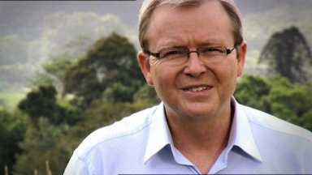

> “Today I have signed the instrument of ratification of the Kyoto Protocol. This is the first official act of the new Australian Government, demonstrating my Government’s commitment to tackling climate change.” - Kevin Rudd, 2007

Ref: What is the Kyoto Protocol? | UNFCCC (2020), Rudd Government Ratifies Kyoto Protocol (2007)

## Introduction Cont.

- Since initial commitments to reduce the greenhouse gas emissions Australia also signed the 2015 Paris Agreement which countries globally agreed to hold the increase in global average temperature to below 2°C and aim to keep them at less than 1.5°C.
- Initial emissions targets we signed committed to a reduction of 26-28% of 2005 levels by 2030
- In 2022, nations met again and Australia increased it’s reductions target to a reduction of 43% by 2030 under the *Climate Change Act (2022)*.
- This was in response to slow initial targets and to commit to The Net Zero Plan for 2050. Where Austrlia aims to have a net 0 greenhouse gas emissions.

[figure not shown]

> Anthony Albanese has signed a commitment to the United Nations that Australia will reduce its emissions by 43 per cent by 2030. (ABC News: Andrew Kennedy)

Ref: International Climate Action - DCCEEW, ABC News (2022)

## Problem Statement

With Australia’s continued promise to reduce greenhouse gas emissions the question is:

**Will Australia meet its 2030 greenhouse gas emissions targets?**

We can analyse this by the following:

- Find and report on the greenhouse gas emissions Australia has measured since they started recording them.
- Understand what changes are being made to reduce this number
- Create a linear regression model to predict the greenhouse gas emissions by 2030
- Use Hypothesis testing to test the validity of the model and the prediction
- Discuss the findings of the model and the data

## Data

Two data sources were used to investigate this question.

1. National Greenhouse Gas Inventory Quarterly Update: September 2023
- A quarterly report on Australia’s greenhouse gas emissions featuring data going back to 2004.
- This data features the emissions produced by each industry and reports the national inventory total.
- The data reported features it’s actual value, a seasonally adjusted value as well as a rolling trend.
1. Energy Account, Australia: 2021-22 financial year
- A yearly report on the supply and use of energy particularly by different sources.
- The data was given in Petajoules (PJ) and shows the energy output of different methods of energy production and how much each industry uses.

Ref: International Climate Action - DCCEEW, Australian Bureau of Statistics (ABS)

## Data Cont.

- Important Variables:
1. The National Greenhouse Gas Inventory (NGGI) features the the date of each quarterly report, the industry, the emissions of that industry and the national inventory total for that quarter. Each value for the emissions was given in million metric tonnes of CO2 equivalent (Mt CO2-e).
2. The 2022 Energy Account had many variables including the metric it was recording, the unit the metric was in, the date and of course value for that year.
- Data processing:

Each data set was imported from an excel file specifying the range of values within a table. These tables were then transposed, had data converted and appropriate variable names given from data within the table.

The data was then cleaned of unneeded variables and tidied using pivot_longer() to adjust the data frame for better use when grouping different industries later.

## Descriptive Statistics and Visualisation

1. National Greenhouse Gas Inventory (2023)

“Emissions in the year to September 2023 were 25.4% below emissions in the year to June 2005 (the baseline year for Australia’s 2030 target under the Paris Agreement).” DCCEEW (2024)

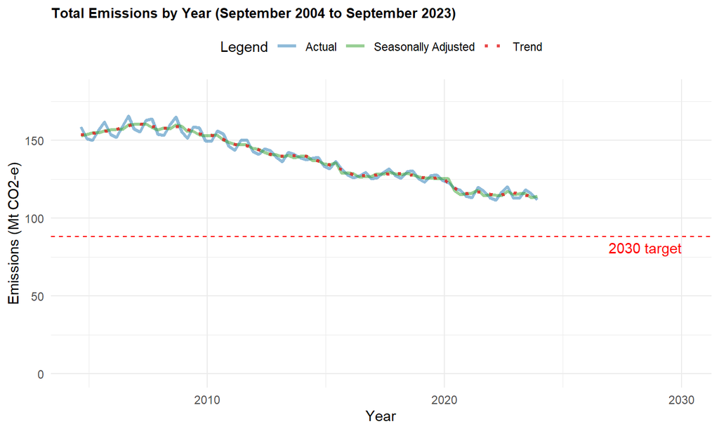

## Descriptive Statistics and Visualisation cont

- This data set also features data about the emissions produced by each industry and looking at these figures gives us a much better understanding of where the reduction in greenhouse gas emissions primarily come from.
- There has been a reduction in electricity emissions but the greatest decrease is in Land use change and forestry. As we can see the sector can actually have negative greenhouse gas emissions (sequestration) if greater amounts of land is used for forests and vegetation.

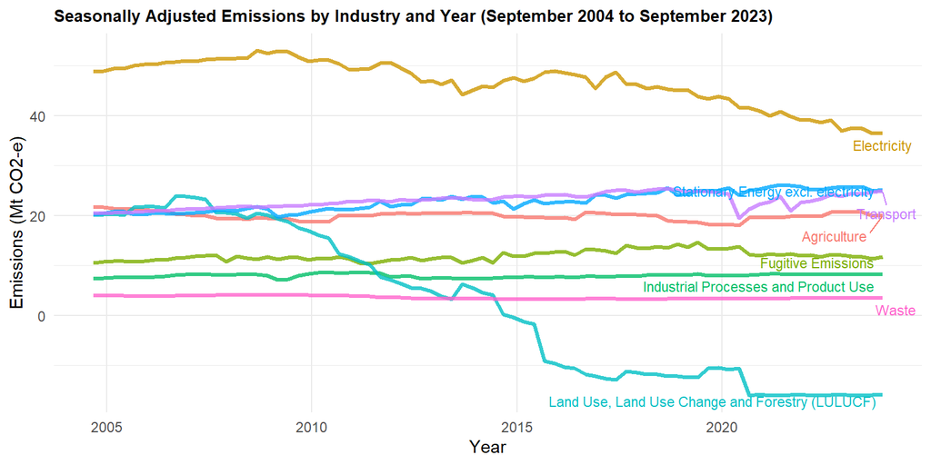

## Descriptive Statistics and Visualisation cont

2.Energy Account, Australia (2022)

- Renewable energy increased by 19% between 2021 and 2022 fiscal years and now makes up 30% of domestic electricity use. This is where we can see a reductions in emissions in electricity.
- Solar increased by 25% (125PJ), Wind by 17% (105PJ) and Hydro by 12% (61PJ).

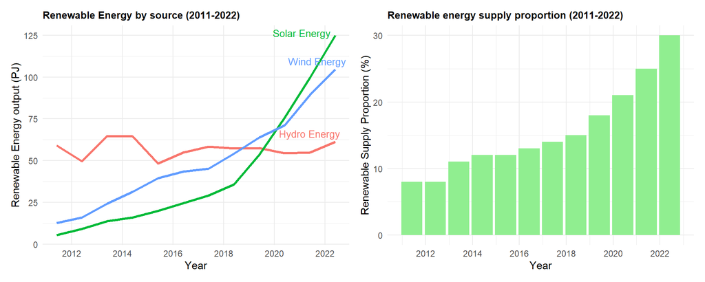

## Decsriptive Statistics Cont.

Here we can see some statistics about the emissions by each industry.

| Industry | Mean Emissions | Standard Deviation | Variance | Sample Size (n) | 2005 Emissions | 2023 Emissions | Percent Change (%) |
| --- | --- | --- | --- | --- | --- | --- | --- |
| Agriculture | 19.92 | 0.80 | 0.64 | 78 | 21.27 | 20.73 | -2.57 |
| Electricity | 46.68 | 4.50 | 20.21 | 78 | 49.46 | 37.37 | -24.44 |
| Fugitive Emissions | 11.93 | 1.00 | 1.01 | 78 | 10.82 | 11.71 | 8.21 |
| Industrial Processes and Product Use | 7.93 | 0.37 | 0.13 | 78 | 7.70 | 8.25 | 7.11 |
| Land Use, Land Use Change and Forestry (LULUCF) | 1.83 | 14.77 | 218.26 | 78 | 20.06 | -16.06 | -180.06 |
| Stationary Energy excl. electricity | 22.89 | 1.92 | 3.68 | 78 | 20.79 | 25.82 | 24.18 |
| Transport | 22.97 | 1.46 | 2.13 | 78 | 20.62 | 24.32 | 17.98 |
| Waste | 3.57 | 0.31 | 0.10 | 78 | 3.94 | 3.47 | -11.92 |

## Regression analysis

- A linear regression model was used on the NGGI data to predict what future emissions could look like in 2030 and beyond.
- A Residuals vs Fitted and a Q-Q plot was used to check the assumption of homoscedasticity and normality. Larger deviations from the model can be attributed to early data before the inflection point in reducing greenhouse gas emissions.
- The Q-Q plot also shows an S-shaped curve which will be discussed later.

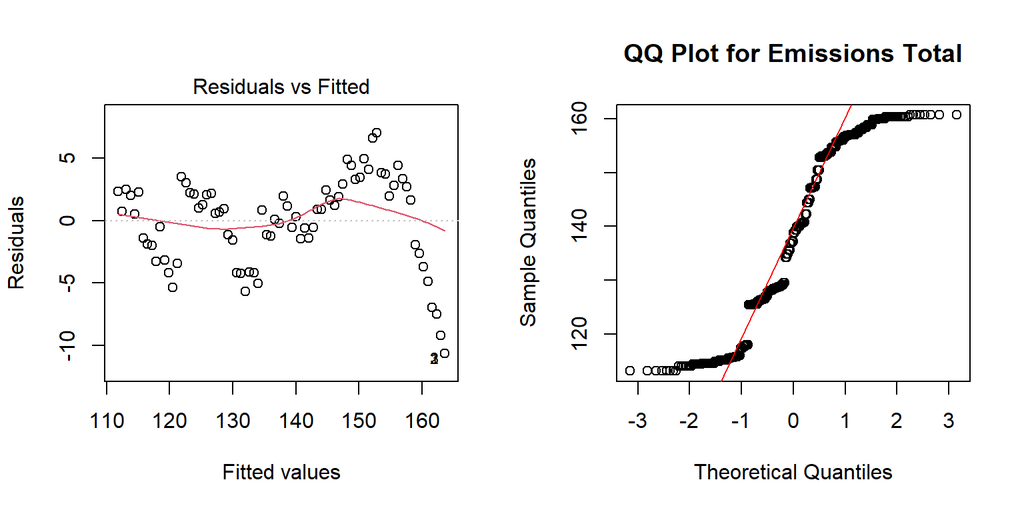

## Regression analysis cont

As we can see at Australia’s current rate we will narrowly miss the emissions target and even more worryingly if we extrapolate this out to 2050 we aren’t close to meeting the target of net zero emissions.

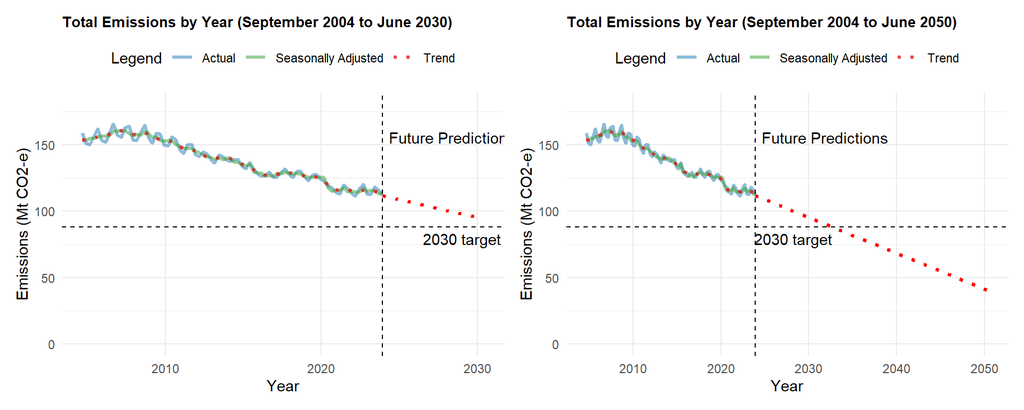

## Regression analysis cont

If we also look at the predictions for each industry to 2030 we see very little change across most industries and a reliance on electricity and land use changes to make the majority of the reductions in greenhouse gas emissions.

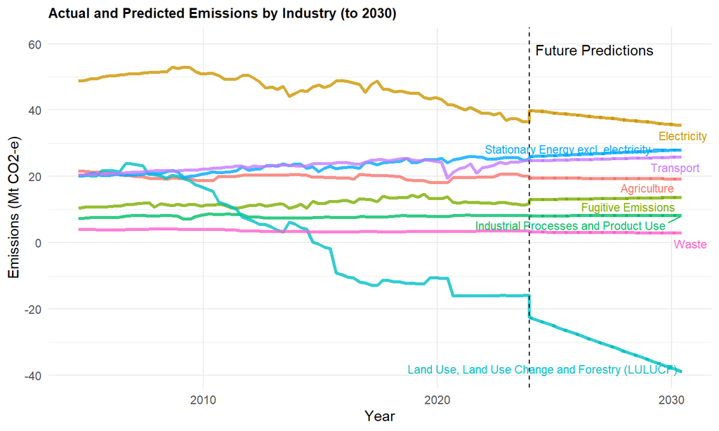

## Hypothesis Testing

We can use a one sample t-test with a confidence interval approach to conduct a hypothesis test on our 2030 regression model prediction.

Where we will use the rule:

$$If the 95% CI does not capture H 0 , reject H 0$$

$$If the 95% captures H 0 , fail to reject H 0$$

### Hypotheses

The null and alternate hypothesis for our test are:

- Null Hypothesis (\(H_0\)): The predicted emissions in 2030 will be equal to or less than the target level, \(H_0 \leq 88.158968\) (Mt CO2-e).
- Alternate Hypothesis (\(H_A\)): The predicted emissions in 2030 will not be equal to or less than the target level, \(H_A \neq 88.158968\) (Mt CO2-e).

## Hypthesis Testing Cont.

- To determine the outcome of the hypothesis test, we calculate the 95% confidence interval of the predicted 2030 emissions value.

The confidence interval is a range where we expect the true emissions in 2030 to be within with a specified confidence of 95%. The spread of the confidence interval is based on the uncertainty and variability of the data that was used to build the regression model.

- The confidence interval and the 2030 predicted emissions for the linear regression model are:

Predicted emissions for 2030: 94.26 million metric tons

Target emissions level: 88.16 million metric tons

Confidence Interval: [93.42, 95.10] million metric tons

- Result:

Since the target emissions level is outside the bounds of the confidence interval of the prediction we can reject the null hypothesis and accept the alternate hypothesis.

## Discussion

- Discuss the major findings of your investigation

The major findings of this investigation is that Australia will likely continue to reduce it’s greenhouse gas emissions but will not hit it’s 2030 target with a high degree of confidence based on current trends. Even more so this is dependant entirely by further reductions in two industries. Further change in emissions from generating electricity via renewable resources and capturing more carbon and facilitating the growth of Australia’s forests and vegetation.

With the Net Zero plan that Australia has signed it also set the target to reach 83% use of renewable electricity, so further emission reductions in electricity are expected. The larger unknown is if we can continue to sequester emissions from the land by increasing carbon stores.

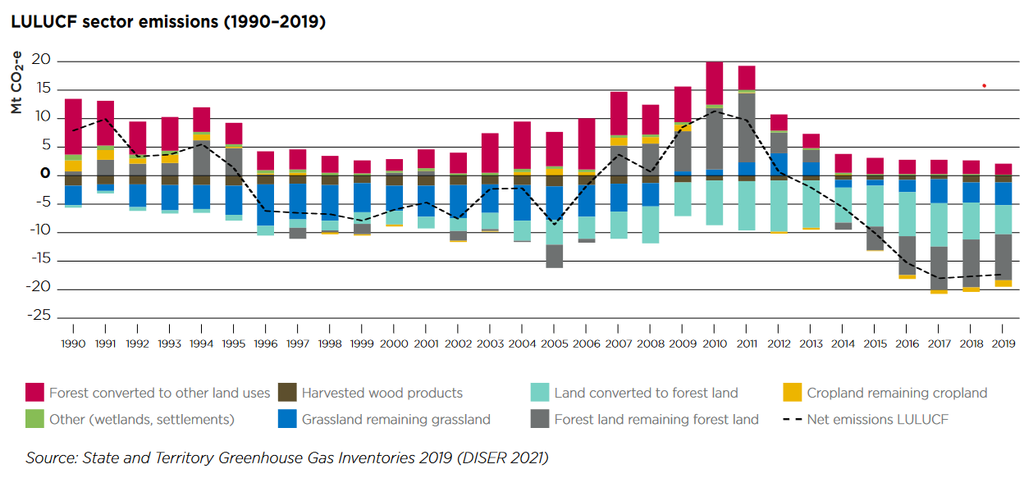

Ref: Victorian Government Action on Climate Change (2022)

## Discussion cont

- Discuss any strengths and limitations.

Linear regression is a good predictive model if there is a strong linear relationship within a data set. The downside is that is is only based off two variables and as we can see when we broke down into individual industries there are several more areas and variables which contribute to Australia’s National Greenhouse Gas Inventory.

The hypothesis test however allows us to show the degree of uncertainty we have in this predicted value. The confidence interval shows the likely range that our true emissions might be in 2030 but is also dependent on the continued linear relationship between greenhouse gas emissions and time. The hypothesis test and confidence intervals also relies on the data following a normal distribution which we tested for using the Q-Q plots earlier, although this showed a S-shaped curve which indicates a light tailed but symmetric distribution.

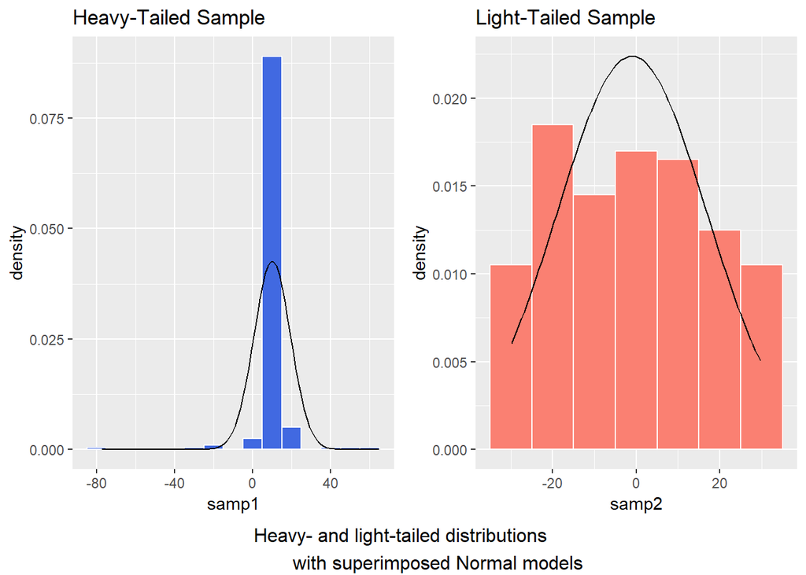

## Discussion cont

- Propose directions for future investigations.

A linear regression model is a great first step in making predictions but looking into other models which can handle more variables would be best. We could also apply more hypothesis tests on more of these variables to see if they have any effect on the net greenhouse gas emissions.

- Conclusion

The linear regression model predicts that we will miss our 2030 emissions target and a hypothesis test was used to analysis the probability in that prediction. The predicted value of 94 (Mt CO2-e) will likely miss the target of 88 (Mt CO2-e) while extrapolating this current trend further also reveals we will miss net zero emissions by 2050.

The Australian Government has pledged to continue to grow the share of renewable energy in generating electricity but several other industries have remained constant with the amount of emissions they produce. Greater amounts of land sequestering is required to offset these emissions and required for Australia to meet it’s 2030 targets and the 2050 net zero targets as well.

## References

- ABC News. “Prime Minister Says He Has ‘drawn a Line’ under Decade of Australia Lagging on Climate Change, as Nation Steps up Commitment.” June 16, 2022. https://www.abc.net.au/news/2022-06-16/australia-updates-emissions-reduction-target-paris-agreement/101157008.
- “Energy Account, Australia, 2021-22 Financial Year | Australian Bureau of Statistics,” December 19, 2023. https://www.abs.gov.au/statistics/industry/energy/energy-account-australia/latest-release.
- “Go Green with Australia | Austrade International.” Accessed October 21, 2024. https://international.austrade.gov.au/en/why-australia/go-green-with-australia.
- “International Climate Action - DCCEEW.” Accessed October 21, 2024. https://www.dcceew.gov.au/climate-change/international-climate-action#toc_0.
- “National Greenhouse Gas Inventory Quarterly Update: September 2023 - DCCEEW.” Accessed October 21, 2024. https://www.dcceew.gov.au/climate-change/publications/national-greenhouse-gas-inventory-quarterly-update-september-2023.
- “Net Zero - DCCEEW.” Accessed October 21, 2024. https://www.dcceew.gov.au/climate-change/emissions-reduction/net-zero.
- “PARIS AGREEMENT (PARIS, 12 DECEMBER 2015) - [2016] ATS 24.” Accessed October 21, 2024. http://www.austlii.edu.au/cgi-bin/sinodisp/au/other/dfat/treaties/ATS/2016/24.html?stem=0&synonyms=0&query=.
- “Rudd Government Ratifies Kyoto Protocol: First Official Decision - AustralianPolitics.Com,” December 3, 2007. https://australianpolitics.com/2007/12/03/rudd-government-ratifies-kyoto-protocol.html/.
- “What Is the Kyoto Protocol? | UNFCCC.” Accessed October 25, 2024. https://unfccc.int/kyoto_protocol.
- Change, Climate. “Victorian Government Action on Climate Change.” Climate Change. Climate Change, October 27, 2022. https://www.climatechange.vic.gov.au/victorian-government-action-on-climate-change.